# Презентация лабораторной работы №10

Расширенные настройки SMTP-сервера

Устинова В. В.

Российский университет дружбы народов, Москва, Россия

4 ноября 2026

# Информация

## Докладчик

- Устинова Виктория Вадимовна
- студент НПИбд-01-24
- Российский университет дружбы народов

# Вводная часть

## Цель работы

Приобретение практических навыков по конфигурированию SMTP-сервера в части настройки аутентификации.

## Сервисы lmtp и auth в Dovecot

В список протоколов добавлен lmtp, в `10-master.conf` определены сервис lmtp (сокет `dovecot-lmtp` для Postfix) и служба аутентификации `service auth` с сокетами `private/auth` и `auth-userdb`.

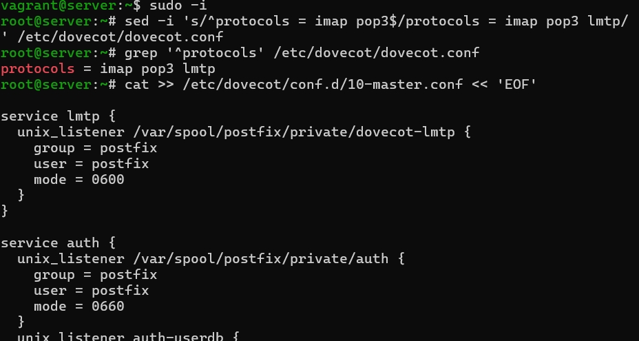

Добавление протокола lmtp и определение сервисов lmtp и auth в 10-master.conf

## Передача почты через LMTP

В Postfix задано `mailbox_transport = lmtp:unix:private/dovecot-lmtp`, в `10-auth.conf` — формат имени пользователя без домена `%Ln`. Postfix и Dovecot перезапущены, Dovecot работает.

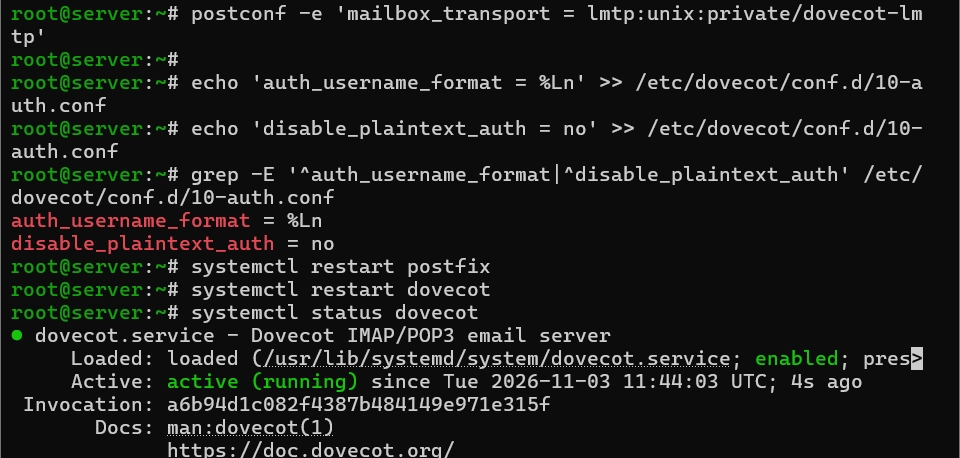

Настройка передачи почты через LMTP, формата имени пользователя и перезапуск служб

## Журнал при доставке через LMTP

С клиента отправлено письмо «LMTP test». Dovecot принял его через сервис lmtp и сохранил в INBOX, Postfix передал письмо через сокет со статусом `status=sent`.

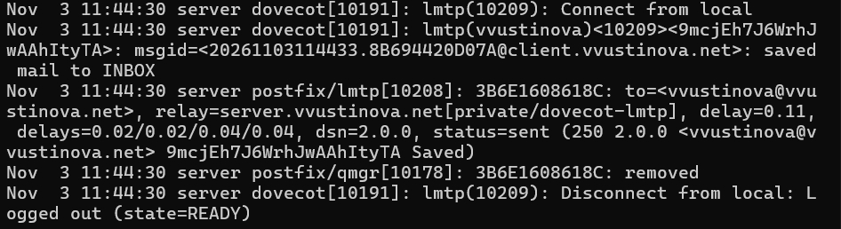

Журнал maillog: письмо принято через LMTP и сохранено в INBOX

## Письмо в ящике пользователя

Почтовый ящик пользователя на сервере просмотрен командой `MAIL=~/Maildir mail`: письмо «LMTP test» доставлено и помечено как новое.

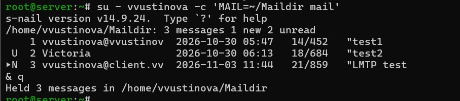

Письмо LMTP test в почтовом ящике пользователя на сервере

## SASL и ограничения получателей

Для Postfix заданы SASL-аутентификация через Dovecot, порядок проверки получателей `smtpd_recipient_restrictions` (защита от relay) и `mynetworks = 127.0.0.0/8`.

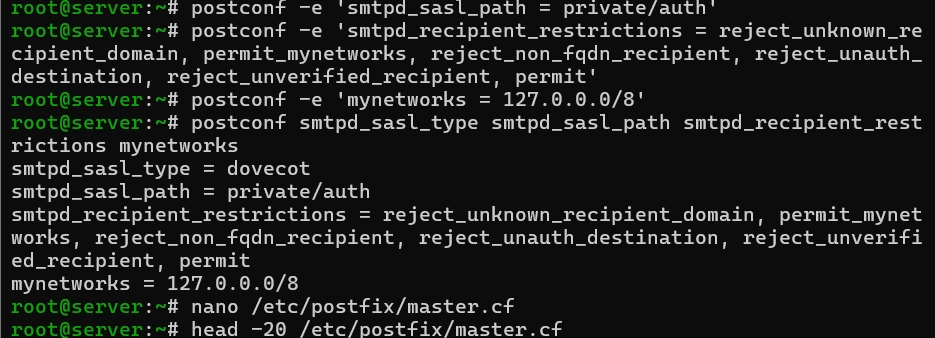

Настройка SASL-аутентификации и ограничений получателей в Postfix

## Временная настройка master.cf

Для проверки аутентификации в `master.cf` для порта 25 временно добавлены `smtpd_sasl_auth_enable=yes` и ограничения получателей для аутентифицированных пользователей.

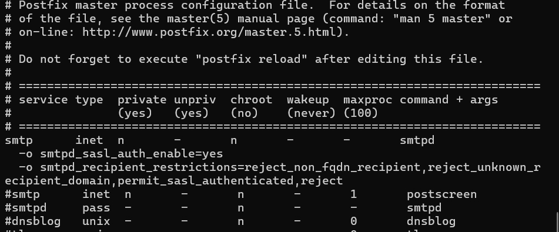

Временная настройка master.cf: SASL-аутентификация на порту 25

## Проверка аутентификации через telnet

На клиенте получена строка для аутентификации в base64 и выполнено подключение к серверу на порт 25. Сервер ответил `235 2.7.0 Authentication successful`.

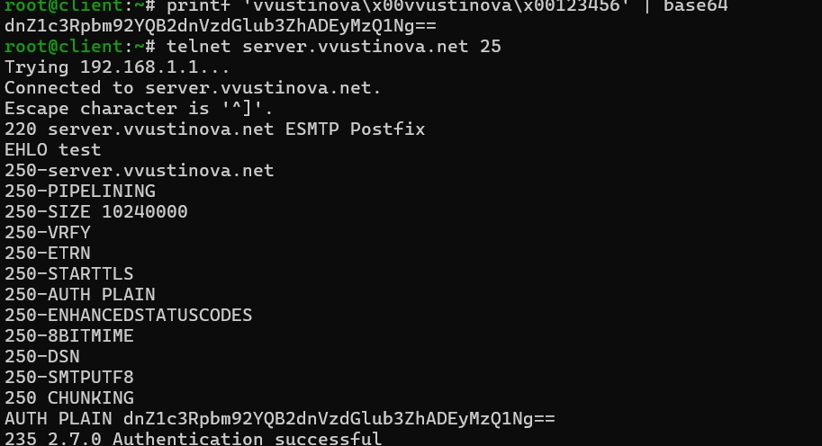

Проверка SMTP-аутентификации на клиенте через telnet

## SMTP поверх TLS

В Postfix указаны сертификат и ключ Dovecot, для порта 587 добавлена служба submission с обязательным шифрованием и SASL-аутентификацией, в межсетевом экране разрешена служба smtp-submission.

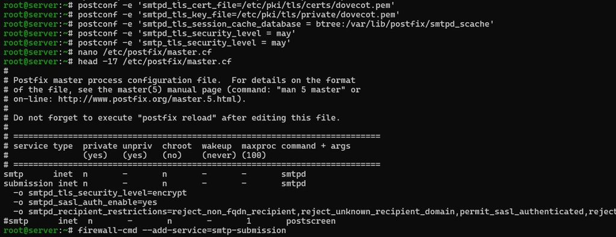

Настройка TLS, службы submission в master.cf и межсетевого экрана

## Настройка Evolution

В Evolution для отправки указаны порт 587, включена аутентификация сервера, шифрование STARTTLS, тип аутентификации PLAIN.

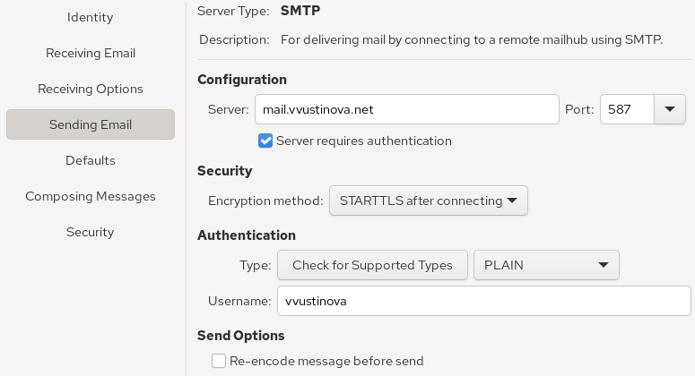

Настройка SMTP в Evolution: порт 587, STARTTLS и аутентификация по паролю

## Отправка из Evolution

В журнале видно подключение клиента с аутентификацией (`sasl_method=PLAIN`) и STARTTLS. Письмо принято Postfix, передано в lmtp и сохранено Dovecot в INBOX.

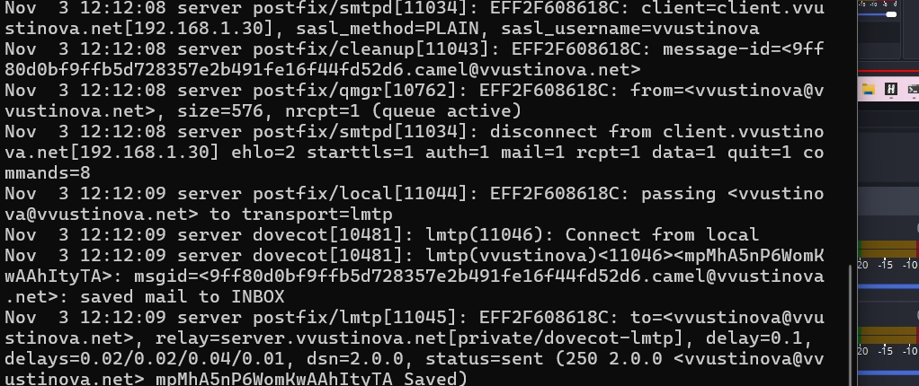

Журнал maillog: отправка из Evolution с аутентификацией и доставка через LMTP

## Скрипт mail.sh для сервера

В скрипт сервера внесены настройки LMTP, SASL-аутентификации, ограничений получателей, `mynetworks` и TLS с копированием сертификата и ключа Dovecot.

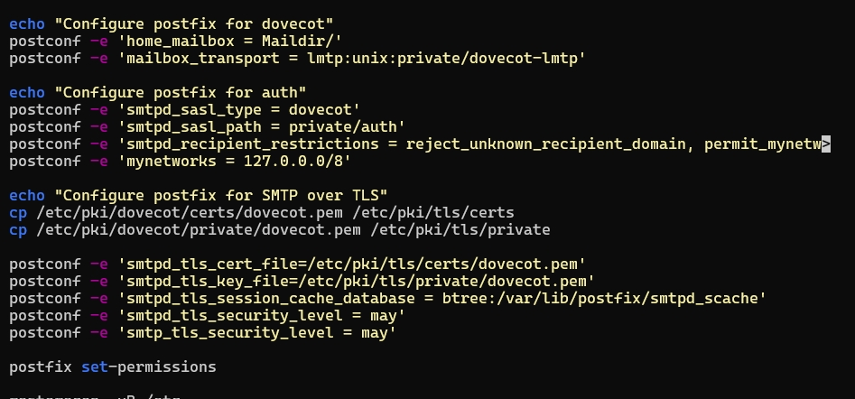

Фрагмент скрипта mail.sh виртуальной машины server

## Скрипт mail.sh для клиента

В скрипт клиента добавлена установка telnet.

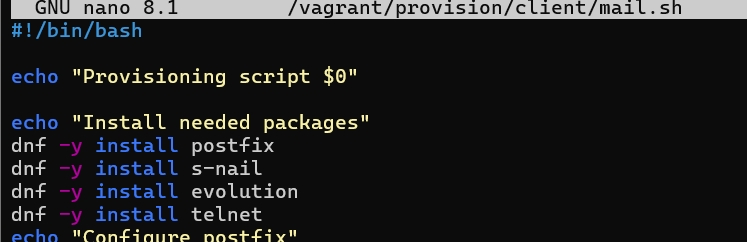

Скрипт mail.sh виртуальной машины client

# Заключение

## Выводы

В ходе работы получены практические навыки по настройке аутентификации на SMTP-сервере. Dovecot настроен для работы с LMTP, а Postfix передаёт ему почту через unix-сокет. Настроена SASL-аутентификация через Dovecot, ограничен приём почты только для обслуживаемых получателей и настроена работа SMTP-сервера поверх TLS на порту 587. Отправка почты с аутентификацией проверена через telnet и через Evolution, изменения зафиксированы в скриптах `mail.sh` для сервера и клиента.